# Reducing Dimensions

Dana Roemling & Annina Van Riper

2025-04-14

# MDA

As usual, we start by setting up our workspace.

```r
library(tidyr)
library(tidyverse)
library(psych)
library(readxl)
library(GPArotation)
library(ggplot2)
library(reshape2)
library(dplyr)
library(gridExtra)

# Change this according to your system & needs
forum_posts_folder <- "/Users/dana/Documents/Teaching (recent)/HY/Week 6/forum/"

# List all .txt files in the folder
all_files <- list.files(forum_posts_folder, pattern = "\\.txt$", full.names = TRUE)

# Filter files by name
dai_files <- all_files[grepl("^DAI", basename(all_files))]
nakamoto_files <- all_files[grepl("^SAT", basename(all_files))]

# read in results excel sheet from MAT
raw_results <- read_excel("/Users/dana/Documents/Teaching (recent)/HY/Week 6/d&n_cleaned stats.xlsx")
```

This chunk below reads in the data into R, in case you want to work with the date itself in here. But for the factor analysis, we’re actually interested in the output of the MAT, which we have already read in in the chunk above. So you could skip this bit.

```r
# Function to read and preprocess a file
read_and_clean <- function(file) {
  text <- read_file(file)
  # Remove punctuation except apostrophes, convert to lowercase
  # text_clean <- tolower(text)
  # text_clean <- str_replace_all(text_clean, "[^\\w\\s']+", "")  # keep apostrophes
  # tibble(filename = basename(file), text = text_clean)
  tibble(filename = basename(file), text = text)
}

# Read all files per author
dai_texts <- map_dfr(dai_files, read_and_clean)
nakamoto_texts <- map_dfr(nakamoto_files, read_and_clean)
```

This chunk handles the results from the MAT and takes only what we need for further analysis. Here, we also check how many dimensions we are interested in given the eigenvalues.

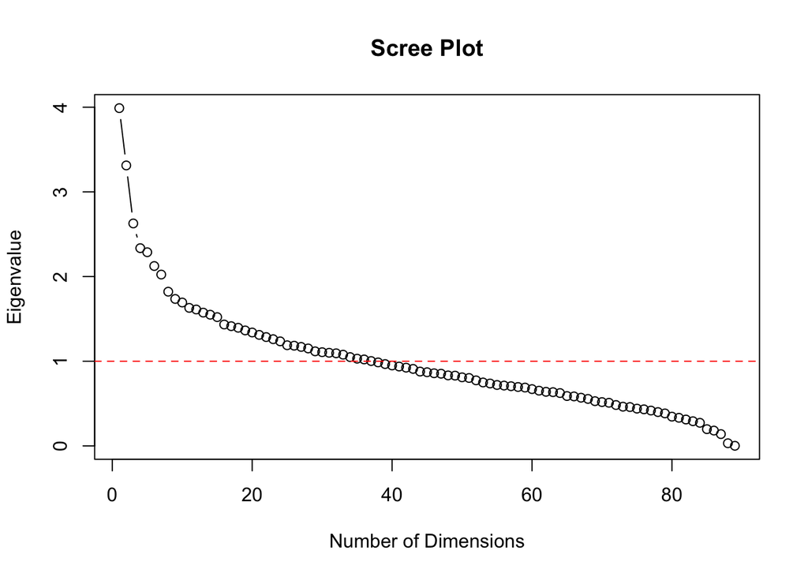

```r
# Clean data: remove columns
# note that this doesn't clean up enough for this particular data set
cleaned_results <- raw_results %>%
  select(-Filename,
         -Tokens,
         -AWL,
         -TTR)

# Or you can delete in bulk, depending on what you need to select
cleaned_results <- raw_results[, -c(1:11)]

# calculate the correlation matrix
cor_matrix <- cor(cleaned_results, use = "complete.obs")

# Get the eigenvalues from the matrix
eigenvalues <- eigen(cor_matrix)$values

# Plot the scree plot
# Note that this is base R and you could do this in ggplot2 if you like
plot(eigenvalues,
     type = "b",
     main = "Scree Plot",
     xlab = "Number of Dimensions",
     ylab = "Eigenvalue")
abline(h = 1,
       col = "red",
       lty = 2)
```

## Factor Analysis

In this bit we do the actual analysis.

```r
## Run factor analysis: oblique rotation
fa4_oblimin <- fa(cleaned_results,
                  nfactors = 4,
                  rotate = "oblimin")
head(fa4_oblimin$scores) # individual text scores
```

```
##             MR1      MR2         MR3         MR4
## [1,] -1.0378172 1.569823 -0.17059276  0.09865026
## [2,] -1.3815215 1.279777  0.05717317  0.32287217
## [3,] -0.9275903 1.343913  0.14362432  0.62812559
## [4,] -1.7488505 1.188122  0.63910332  0.42888162
## [5,] -0.3563470 1.100884 -0.21161306  0.89001844
## [6,] -3.8107176 1.828932  0.65398851 -0.26008739
```

```r
# extract the scores
TextScores <- as.data.frame(fa4_oblimin$scores)

# Add column wrt text type
TextScores <- TextScores %>%
  mutate(TextType = ifelse(row_number() <= 231, "Dai", "Nakamoto"))
head(TextScores)
```

```
##          MR1      MR2         MR3         MR4 TextType
## 1 -1.0378172 1.569823 -0.17059276  0.09865026      Dai
## 2 -1.3815215 1.279777  0.05717317  0.32287217      Dai
## 3 -0.9275903 1.343913  0.14362432  0.62812559      Dai
## 4 -1.7488505 1.188122  0.63910332  0.42888162      Dai
## 5 -0.3563470 1.100884 -0.21161306  0.89001844      Dai
## 6 -3.8107176 1.828932  0.65398851 -0.26008739      Dai
```

```r
TextScores$TextType <- factor(TextScores$TextType, levels = c("Dai", "Nakamoto"))
```

## Plotting

Now that we have the scores depending on the level, in this case the authors, we can have a look at them in the form of box plots. We can either create the plots separately (first chunk) or do it in one go (second chunk).

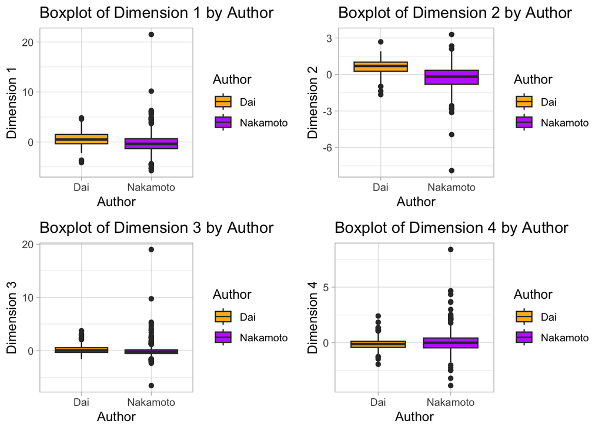

```r
# Box plot for MR1
BPMR1 <- ggplot(TextScores, aes(x = TextType, y = MR1, fill = TextType)) +
  geom_boxplot()+
  labs(title = "Boxplot of Dimension 1 by Author", x = "Author", y = "Dimension 1") +
  theme_light() +
  scale_fill_manual(values = c("Dai" = "darkgoldenrod1", "Nakamoto" = "darkorchid1")) +
  labs(fill = "Author")
#print(BPMR1)

# Box plot for MR2
BPMR2 <- ggplot(TextScores, aes(x = TextType, y = MR2, fill = TextType)) +
  geom_boxplot()+
  labs(title = "Boxplot of Dimension 2 by Author", x = "Author", y = "Dimension 2") +
  theme_light() +
  scale_fill_manual(values = c("Dai" = "darkgoldenrod1", "Nakamoto" = "darkorchid1")) +
  labs(fill = "Author")
#print(BPMR2)

# Box plot for MR3
BPMR3 <- ggplot(TextScores, aes(x = TextType, y = MR3, fill = TextType)) +
  geom_boxplot()+
  labs(title = "Boxplot of Dimension 3 by Author", x = "Author", y = "Dimension 3") +
  theme_light() +
  scale_fill_manual(values = c("Dai" = "darkgoldenrod1", "Nakamoto" = "darkorchid1")) +
  labs(fill = "Author")
#print(BPMR3)

# Box plot for MR4
BPMR4 <- ggplot(TextScores, aes(x = TextType, y = MR4, fill = TextType)) +
  geom_boxplot()+
  labs(title = "Boxplot of Dimension 4 by Author", x = "Author", y = "Dimension 4") +
  theme_light() +
  scale_fill_manual(values = c("Dai" = "darkgoldenrod1", "Nakamoto" = "darkorchid1")) +
  labs(fill = "Author")
#print(BPMR4)

# Arrange them in a 2x2 grid
grid.arrange(BPMR1, BPMR2, BPMR3, BPMR4, ncol = 2)
```

So this is the combined version.

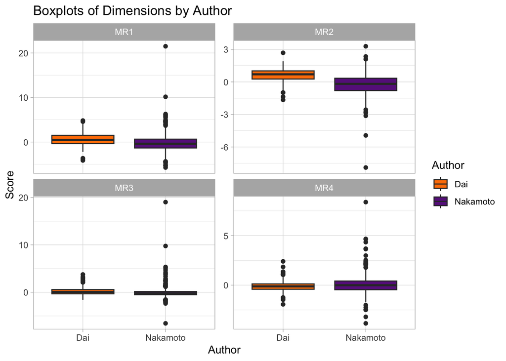

```r
TextScores_long <- TextScores %>% #reshape data
  pivot_longer(cols = starts_with("MR"),
               names_to = "Dimension",
               values_to = "Score")

# Create the combined plot

combined_plot <- ggplot(TextScores_long, aes(x = TextType, y = Score, fill = TextType)) +
  geom_boxplot() +
  facet_wrap(~ Dimension, scales = "free_y") +
  labs(title = "Boxplots of Dimensions by Author", x = "Author", y = "Score") +
  theme_light() +
  scale_fill_manual(values = c("Dai" = "darkorange1", "Nakamoto" = "darkorchid4")) +
  labs(fill = "Author")
print(combined_plot)
```